# S9 Factores condicionantes para el rendimiento académico

```r
library(readr)
```

**————————————————————————————————————————————————————————–**

*Barranco, Perú (2022).*

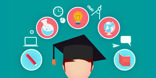

**————————————————————————————————————————————————————————–**

# 1 **Introducción**

## 1.1 Relevancia

| **Motivación** | En un contexto donde la presencialidad está de vuelta, después de más de dos años de pandemia, en donde la educación a distancia se robó el protagonismo y nosotros (los estudiantes de UTEC) no estamos… |
| --- | --- |
| **Importancia** | La realización del presente estudio es de gran interés debido a que los estudiantes aspiramos a tener un buen rendimiento académico, ó, en el peor de los casos, a tener uno en el que aprobemos los div… |

## 1.2 **Planificación**

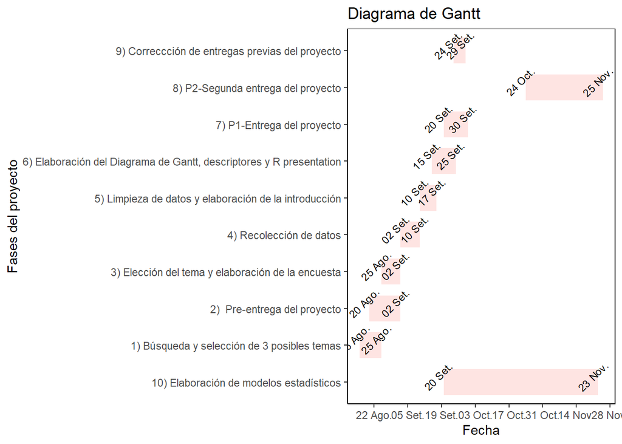

```r
pl <- ggplot(df.melt, aes(x = value, y = Stage, colour = Complete ))
pl <- pl + geom_line( alpha = 0.2, size = 10)
pl <- pl + geom_text(aes(label = format(value, "%d %b")), vjust = -0.5, angle = 45, size = 3, color = "black")
pl <- pl +   theme_classic()
pl <- pl + labs(title = "Diagrama de Gantt")
pl <- pl + labs(x = "Fecha")
pl <- pl + labs(y = "Fases del proyecto")
pl <- pl + theme(legend.position = "write")
pl <- pl + theme(panel.background = element_rect(color = "black"))
pl <- pl + scale_x_date(name = "Fecha"
                        ,  date_labels = "%d %b"
                        ,  date_breaks = "2 week"
                        , minor_breaks = "1 day")
pl
```

**————————————————————————————————————————————————————————–**

# 2 **Datos**

## 2.1 **Recolección de datos**

Los datos se recolectaron de la siguiente manera:

1. Se creó una encuesta en Google forms tomando en consideración variables asociadas con llevar una vida saludable estableciendo ciertas restricciones para obtener datos más exactos.
2. La encuesta se desarrolló en una semana, y se logró recolectar 200 datos.
3. Al observar que se recolectaron datos atípicos se procede a hacer la limpieza de la data con el objetivo de facilitar la manipulación de los mismos y además de que nos permite tener una investigación más coherente.

## 2.2 **Población, muestra y muestreo**

| **Población** | Estudiantes universitarios del Perú. |
| --- | --- |
| **Muestra** | Estudiantes de la UTEC. |
| **Muestreo** | Muestreo aleatorio simple. |

**————————————————————————————————————————————————————————–**

# 3 **Análisis descriptivo**

**Moda de los alimentos que consumen los estudiantes**

```
## la moda de la varible Alimentos    es  :  Un poco de ambos
```

En nuestro estudio esta variable la vamos a considerar como uno de los factores que afecta al rendemiento academico , lo usaremos para poder identificar si es que esta variable condiciona o no a los estudiantes y si lo hace que tanto es su impacto, midiendo su tendencia podemos determinar que tanto influyen en nuestra muestra .

**Variable: cursos desaprobados**

```
## La moda de la varible Cursos desaprobados es   :  0
```

```
## La desviacion estandar  de  la variable  Cursos desaprobados es  :  1.51
```

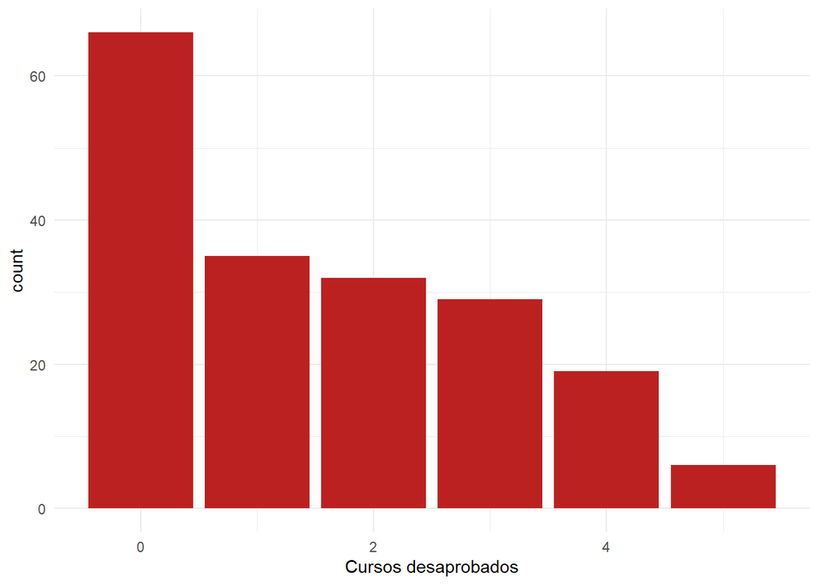

Esta variable de cursos desaprobados es importante ya que por lo general esta se relaciona con el rendimiento académico.

**Promedio Ponderado**

**Rango de ponderado de los estudiantes**

¿Cuál es el rango del promedio ponderado?

```
## El rango del ponderado del los estudiantes es [ 12 17.81 ]
```

**Promedio del ponderado de los estudiantes** ¿Cuál fue el promedio del ponderado de los estudiantes?

```
## El promedio del ponderado de los estudiantes es:  14.47626
```

**Coeficiente de varianza del ponderado de los estudiantes**

```
## El coeficiente de varianza con respecto promedio ponderado es:  9.12
```

**Distribución del promedio ponderado**

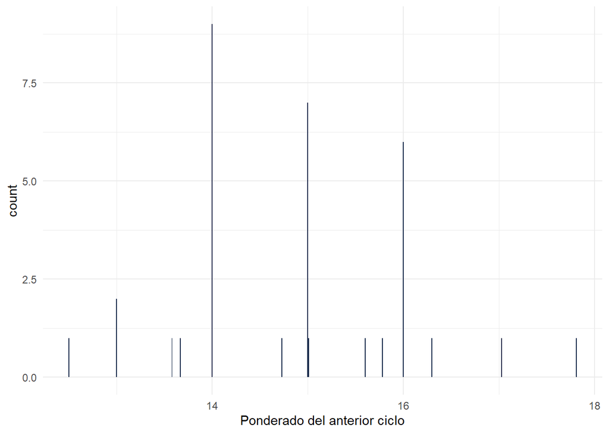

**Variable: Cursos matriculados**

Saber la cantidad de cursos en los que se matricularon los estudiante es una de las variables relevantes que necesitaremos , porque al igual que el ponderado esta muy estrechamente relacionado en el ambito academico, el cual también necesitamos para relacionar con otras variables para ver qué tanto influye este factor en nuestra muestra, con ello tener un panorama más amplio de nuestra investigación.

**Moda**

```
## la moda de la varible Cursos te has matriculado  es   :  6
```

**Coeficiente de Varianza**

```
## El coeficiente de varianza con respecto  a los cusos  que se matricularon es:  14.93
```

**Gráfico de Cursos Matriculados**

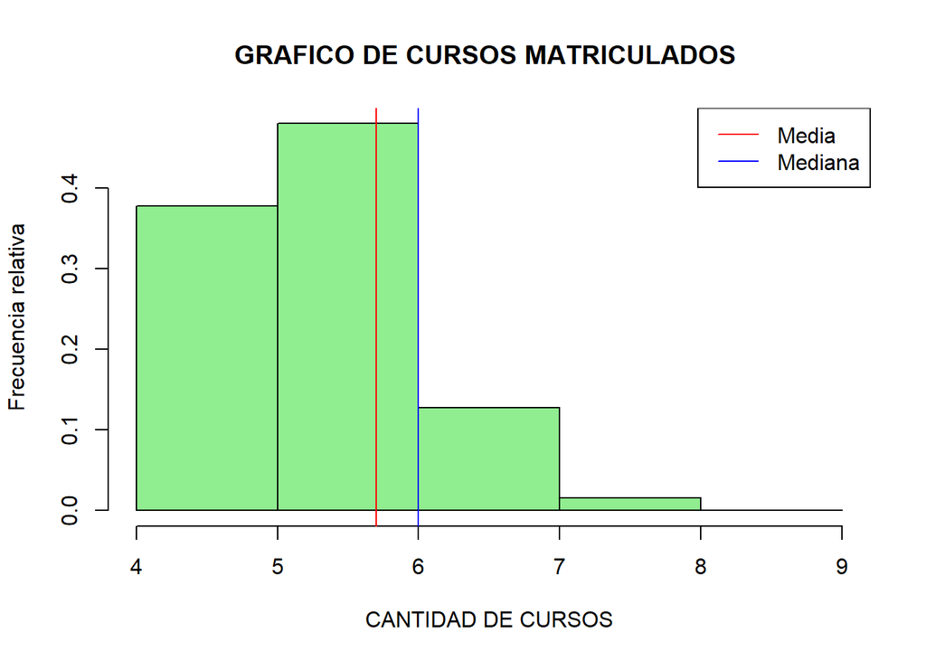

**Variable: Nivel de estrés**

Conocer el nivel de estres y relacionarlo con uno de los factores que condicionan al rendimiento es vital , puesto que es uno de los agentes que mas se presentan al momento de desarrollarse profesionalmente , el estres esta por lo general conviviendo en todos los estudiantes , saber identificar y medir que tanto esta presente cuantitativamente y relacionarla es uno de los puntos primordiales en nuestra investigación , esta variable es relevante gracias a ella observaremos si los condiciona de manera negativa o postivamente .

**Moda**

```
## La moda de la varible  estres es   :  4
```

**Desviacion estandar**

[output not shown]

**Diagrama de bigote: Nivel de estres**

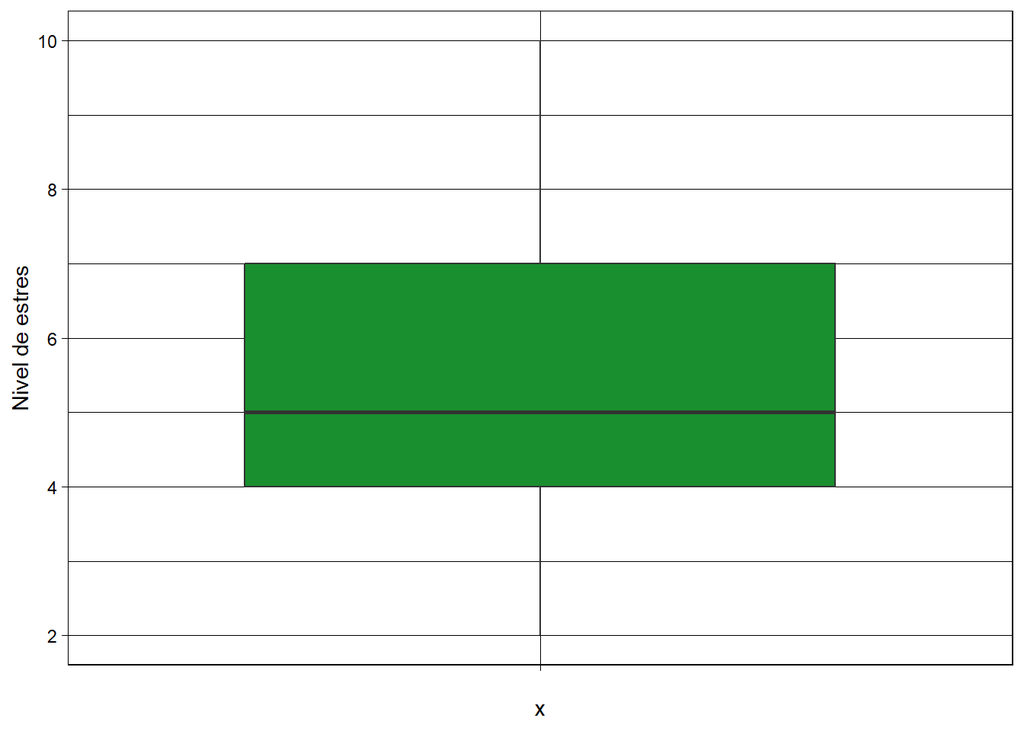

**Variable: Deporte**

Esta variable deporte nos sirve como base y sustento para poder determinar si condiciona ya que esta relacionada sobre todo con la salud fisica y mental los cuáles son 2 cosas que deben de estar perfectamente sanas, para que los estudiantes tengan un buen rendimiento académico , saber si la mayoría de nuestra poblacion cumple con este requisito nos llevara a poder sacar conclusiones mucho más certeras para nuestra investigación.

**Moda**

```
## La moda de la variable deporte es  :  No
```

**Gráfico Sobre deporte**

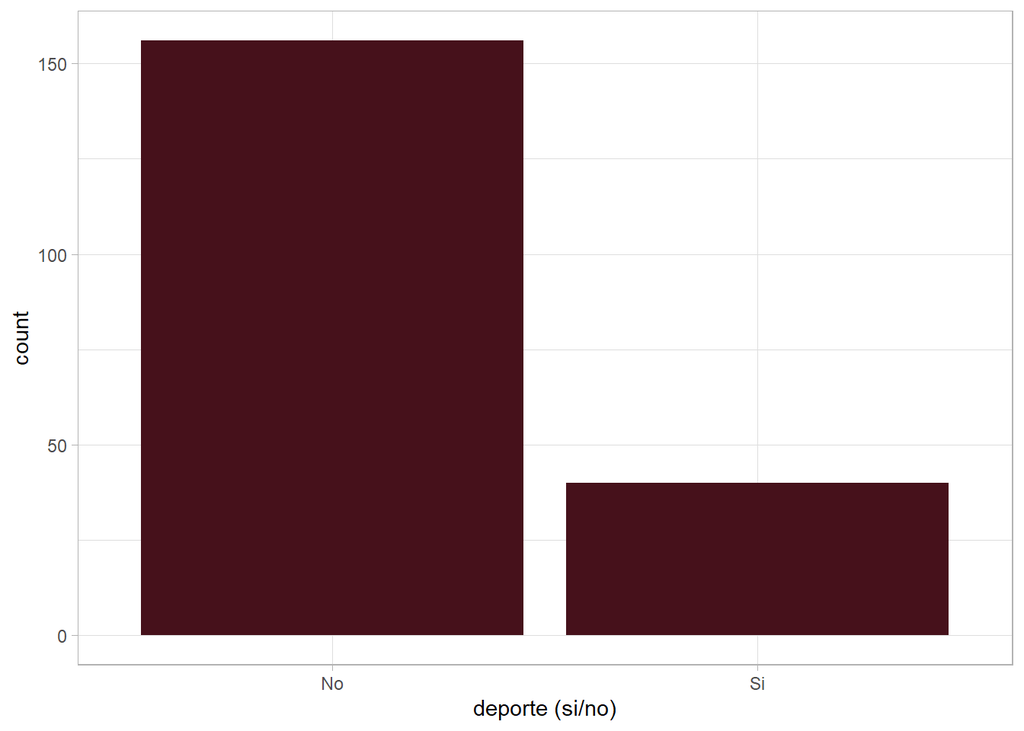

**Variable: Horas de estudio**

**Frecuencia de las distintas horas de estudio de los estudiantes**

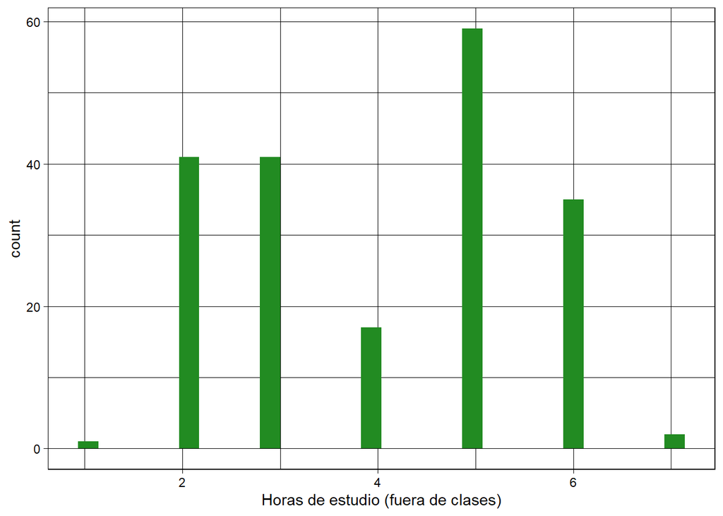

**Relación entre vida saludable y estado socieconómico**

¿Existe relación entre vida saludable y estado socieconómico?

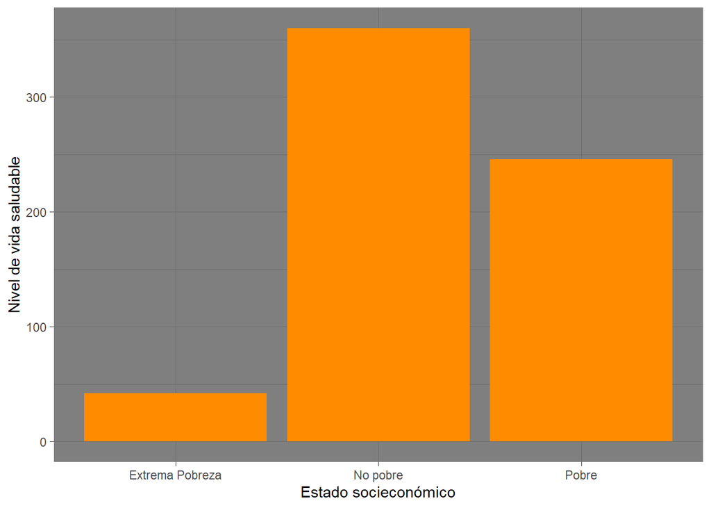

**Nivel de estrés y promedio**

El siguiente gráfico nos muestra la relación entre el nivel de estrés y el promedio ponderado. De esta forma, se observa como mediante mayor nivel de estrés se obtiene un menor promedio ponderado. Por otro lado, el coeficiente de correlación nos brinda un valor que nos ayuda a soportar esta idea.

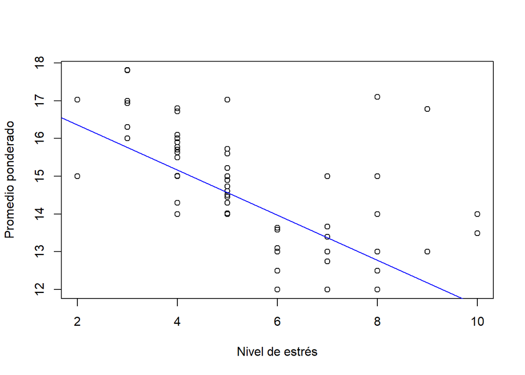

```
## El coeficiente de correlación entre las variables es:  -0.7143485
```

**Nivel de estres y ciclo**

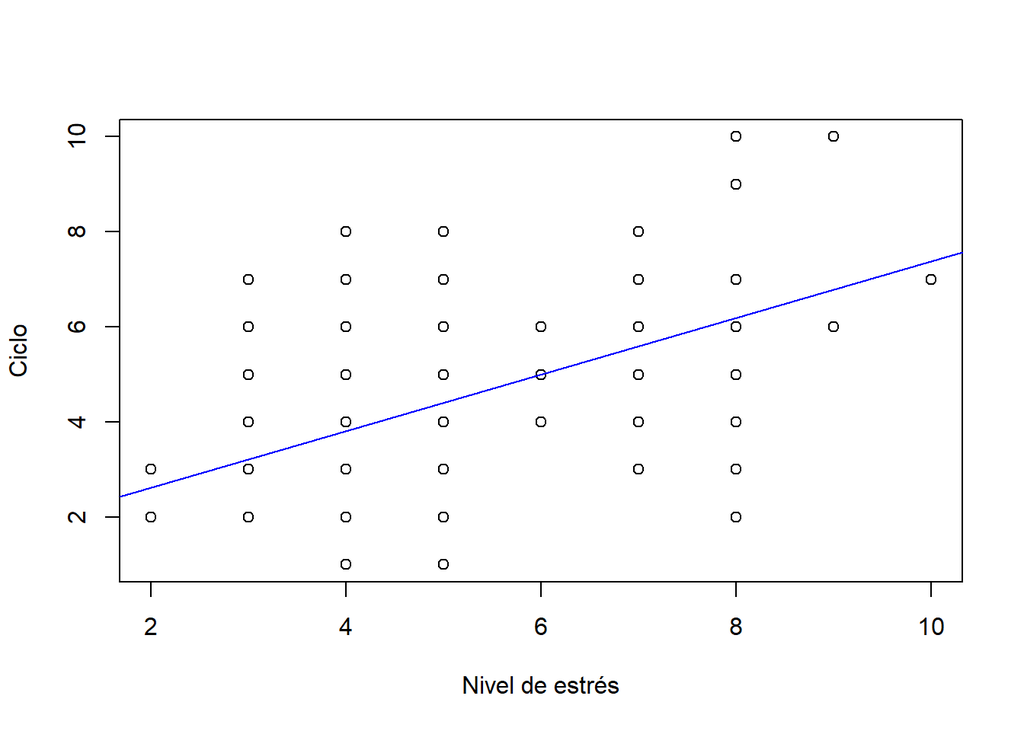

```
## El coeficiente de correlación entre las variables es:  0.5646123
```

**Horas de estudio y promedio ponderado**

El siguiente gráfico nos muestra la relación entre horas de estudio y el promedio ponderado. De esta forma, se observa como mediante más horas de estudio se obtienen mejores promedios ponderados. Por otro lado, el coeficiente de correlación nos brinda un valor que nos ayuda a soportar esta idea.

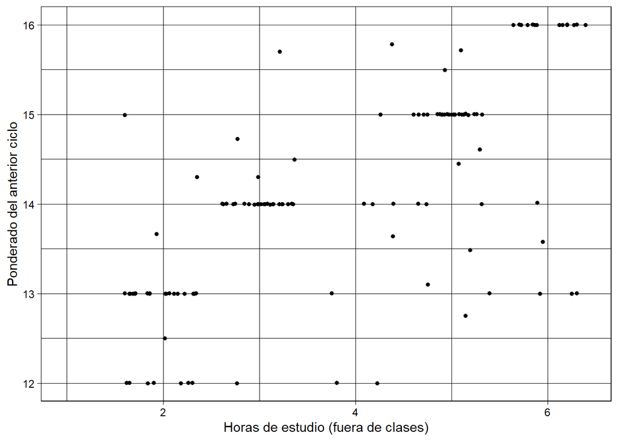

```
## El coeficiente de correlación entre las variables es:  0.5881901
```

**Horas de ocio y promedio ponderado**

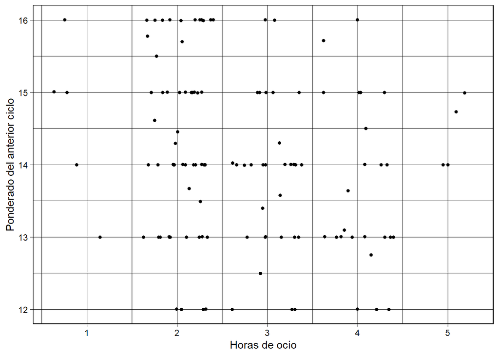

```
## El coeficiente de correlación entre las variables es:  -0.3299164
```

**Consideraciones**

Mostramos la matriz de correlaciones para poder observar que tanto estan relacionadas nuestras variables se puede observar en en gráfico que existen variables con valores aceptables de correlación y otros con correlación negativa , por ejemplo : *Horas de ejercicio* tiene una relación aceptable con el ponderado pero negativa con la variable *Cantidad de cursos que llevas actualmente en el ciclo* **

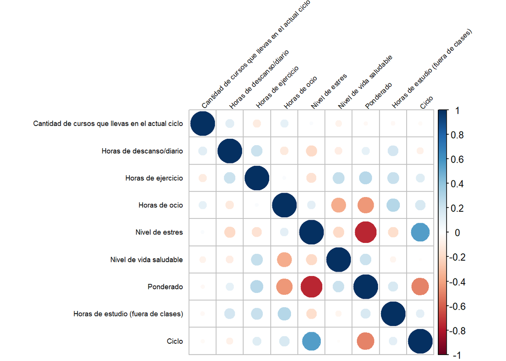

```r
#install.packages("corrplot")
DFCORR <- data_2 %>% select(`Cantidad de cursos que llevas en el actual ciclo`,`Horas de descanso/diario`,`Horas de ejercicio`,`Horas de ocio`,`Nivel de estres`,`Nivel de vida saludable`,Ponderado,`Horas de estudio (fuera de clases)`,Ciclo)
library("corrplot")
corrplot(cor(DFCORR, use = "complete.obs"), tl.cex = 0.6, tl.srt = 45, tl.col = "black")
```

# 4 **Análisis probabilístico**

En esta sección vamos a proponer diversos ejercicios de probabilidaes en relación a las variables que hemos considerado necesarias, asimismo, determinar que distribución siguen las variables.

**Análisis de Ponderado y Horas de estudio (Caso de Probabilidad Condicional)**

Considerando la definición de probabilidad condicional y además que nuestro experimento consiste en poder retirar una de las personas que cumplan una determinada condición , en la cual cada uno de estos tienen la misma probabilidad de poder ser escogidos , podemos preguntarnos lo siguiente:

*¿Cuál es la probabilidad condicional de obtener un Ponderado mayor que nuestra media dado que un* *estudiante estudio mas que la media ?*

**Nota :**

- P = Ponderado
- H = Horas de estudio

Esto lo podemos representar como :
$$\frac {P(P > 14.47626 \ \ ∩ \ H > 4.045918 )}{P( H
>4.045918)}$$

```
## [1] 0.8
```

$${----------------------------------------------------------}$$

$${RESPUESTA \ \ = \ \ La
\ \ probabilidad \ \ es \ \ de \ \ 0.8\ }$$
$${----------------------------------------------------------}$$

Teniendo en cuenta este razonamiento podemos preguntarnos :

*¿Cuál es la probabilidad condicional de obtener un Ponderado mayor que nuestra media dado que un* *estudiante estudió menos que la media ?*

Lo podemos representar :

$$\frac {P(P > 14.47626 \ \ ∩ \ H
<= 4.045918 )}{P( H <=4.045918)}$$

```
## [1] 0.1956522
```

$${----------------------------------------------------------}$$
$${RESPUESTA \ \ = \ \ La
\ \ probabilidad \ \ es \ \ de \ \ 0.196\ }$$
$${----------------------------------------------------------}$$

*Interpretación*:

- Pregunta 1 : Podemos observar que aquel estudiante que estudio mas que la media entonces tendra muchas mas posibilidades de poder tener mas ponderado que la media .
- Pregunta 2 : Observamos que si un estudiante estudio menos que la media , entonces las posiblidades que tenga un mayor ponderado sera menor a la media .

*Conclusión*:

- A partir de ello, podemos determinar que un estudiante que estudia más horas al promedio, entonces podrá tener un ponderado mucho mayor , y esto ciertamente tiene sentido dado que nuestro diagrama de correlación nos lo indica.

**Analísis de la variable Becado**

Observamos que nuestra variable nos brinda data para una distrbucion Binomial ya que solo presenta dos posibles valores el de becado y no becado, así podemos tener:

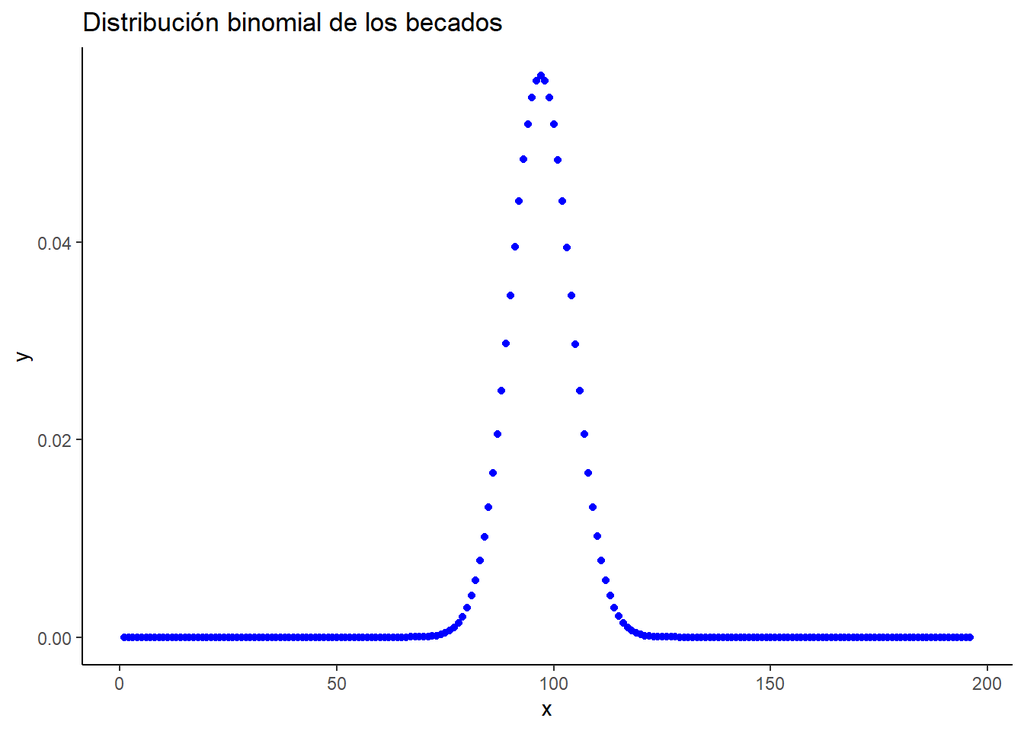

```r
### Transformamos a binomial
### Definimos SI como exito
minidf = as.data.frame(table(data$Becado))
n = nrow(data)
x = 1:n
p = minidf$Freq[2]/sum(minidf$Freq)
y = dbinom(x,n,p)
bino  = cbind.data.frame(x,y)
ggplot(bino,aes(x,y)) +
        geom_point(col="blue") +
        theme_classic() +
        ggtitle("Distribución binomial de los becados")
```

En este caso podemos seguir un modelo Bernuli en donde Eθ , 0 no es becado y 1 es becado en donde podemos decir que deriva la variable Bernuli θ , tomamamos como 0 fracaso y 1 como exito .

$${ \ U_θ \ ∼ Bin(P)}$$
Encontraremos la variable que vamos a necesitar en este caso:

```r
 data_new <-  data_2$Becado
 DF2 <- data.frame(data_new)
 DF2$data_new[DF2$data_new=='No'] <-0
  DF2$data_new[DF2$data_new=='Sí'] <-1
    value<- sum(as.numeric(DF2$data_new)/nrow(data_2))
    round(value,digits = 2)
```

```
## [1] 0.49
```

Entonces partiendo de estos resultados planteamos algunas de estas preguntas :

```
## [1] 0.494898
```

Si escogemos aleatoriamente 30 estudiantes de UTEC *¿Cuál es la probabilidad de que al menos la mitad de ellos sea becado ? ¿cuál es el número de alumnos del grupo son becados en promedio?*

Considerar :

- Variables a utilizar 30
- Prob = 0.49

$${ N ∼ Binom(30 \ , \
0.494898) \ }$$
Esta pregunta la podemos interpretar como :
$${ P( N >= 15)}$$
Entonces tenemos :
$${ PROBABILIDAD \ \ DE \ \ QUE \
\ ESTO \ \ OCURRA \ \ ES \ \ DE \ \ : \ \ 0.55 }$$

```
## [1] 0.55
```

Ahora para poder responder a la segunda pregunta basta con la formula de la esperanza de una Binomial donde tenemos :
$${ n = 30 \ \ y \ P=0.494898 \
\ }$$

```
## [1] 14.85
```

$${-------------------------------}$$
$${ n * p = \ \ 14.85 }$$
$${-------------------------------}$$

**Interpretación**

**Conclusión**

¿Cuántos alumnos de los Utec tenemos que entrevistar en promedio hasta poder encontrar un estudiante que sea becado ?

**Nota :**

- *L* cuenta el numero de intentos del Experimento Eu hasta poder obtener el primer éxito . Para ello vamos a utilizar una variable el cual sera geométrica con parametra *P*.

$$\frac {1 }{P}$$

```r
round(1/Prob,digits = 2)
```

[output not shown]

**APLICAMOS UN MODELO NORMAL**

**Análisis de la variable Ponderado**

Observamos que a través de un histograma nuestra Variable Ponderado tiende a seguir una distribución normal, entonces dado esto podemos plantear las siguientes preguntas:

*GRAFICA*

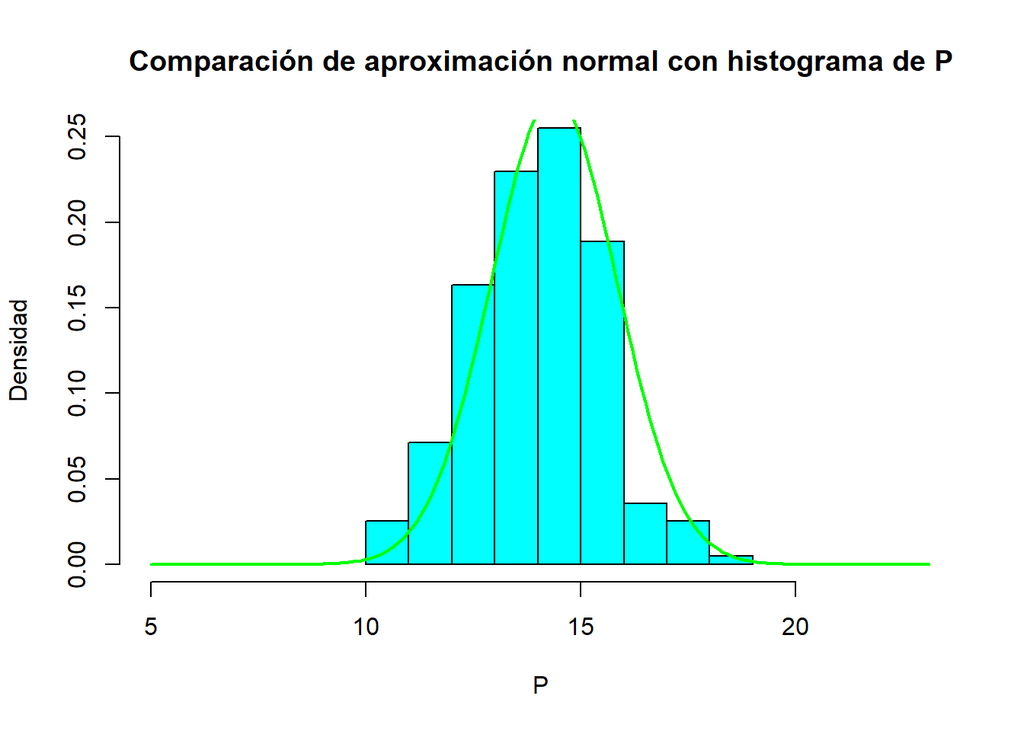

```r
    # install.packages('fitdistrplus')
  P <-data_2$Ponderado[!is.na(data_2$Edad) & data_2$Edad!= 0]
#des
  Mu <- mean(P)
Sigma <- sd(P)
Xs <- seq(min(P) - 5, max(P) + 5, 0.1)
Ys <- dnorm(Xs, mean=Mu, sd=Sigma)
hist(P, prob=TRUE, ylim=c(0, 0.25), xlim=c(min(P) - 5, max(P) + 5), breaks=10, ylab="Densidad", main=paste("Comparación de aproximación normal con histograma de P"), col="cyan")
lines(Xs, Ys, type="l", col="green", lwd=2)
```

$${ p ∼ \ \ Nor (\ \ μ , \ \
σ)}$$

```r
 v  <-data_2$Ponderado[!is.na(data_2$Ponderado)  & data_2$Ponderado!=0]
  desviacion <-sd(v)
   m <- mean(v)
```

**PREGUNTAS DE PROBABILIDAD**

Entonces teniendo en consideración esto nuestro modelo se puede representar como :

```r
 f <-pnorm(11, mean=m, sd=desviacion, lower.tail=FALSE)

  round(f,digits = 2)
```

```
## [1] 0.99
```

$${RESPUESTA \ \ = \ \
0.99}$$

¿Cuál es la probabilidad que tenemos de obtener de promedio que tenga un promedio aceptable en una universidad de los Estados Unidos, en donde sabemos que el cuarto quintil de los alumnos cumpliría de UTEC con esos requisitos?

```r
a <-qnorm(0.8,mean=m ,sd=desviacion)
b <- 1 - pnorm(a,m,desviacion)
round(b,digits = 2)
```

```
## [1] 0.2
```

$${RESPUESTA =\ \ 0.2 }$$

**Interpretación**

- En la primera pregunta se puede identificar que la gran mayoría de alumnos aprueban con un promedio mayor o igual a 11.
- En la segunda pregunta podemos decir que si comparamos el nivel educativo de los estudiantes de nuestra universidad con las de Estados Unidos, entonces habría una posibilidad de 0.2 que nuestros alumnos se pueden desarrolllar de manera regular.

**Conclusiones**

- Por lo general, los alumnos de UTEC se desempeñan de manera regular porque casi todo el alumnado obtiene un ponderado mayor o igual a 11, por otro lado, existe una probabilidad de 0.2 para que el alumnado se pueda desenvolver académicamente en una universidad de USA.

**APLICAMOS UN MODELO HIPERGEOMETRICO**

Variable: Carrera

Problema:

Para este problema tomamos a la variable de tipo categórica ordinal, carrera que estudian los alumnos de UTEC.

```r
table(data_2$Carrera)
```

```
##
## Administración y negocios digitales                       Bioingeniería
##                                   7                                  21
##                    Ciencia de datos          Ciencias de la Computación
##                                   8                                  22
##                          Ing. Civil                  Ing. de la energía
##                                  29                                  10
##                    Ing. Electrónica                       Ing. Mecánica
##                                   6                                   9
##                       Ing.Ambiental                      Ing.Industrial
##                                  27                                  34
##                     Ing.Mecatrónica                         Ing.Química
##                                   6                                  16
```

1. Supongamos que se toma a 30 de ellos para realizar un sorteo. ¿Cuál es la probabilidad de que al menos 10 estudiantes sean de la carrera de ingeniería industrial?

$$M=34,N=196,xo=10,n=30$$

Donde:

M: Cantidad total de éxitos en la población

N: Población

xo: Número de éxitos en la muestra

n: Cantidad de la muestra

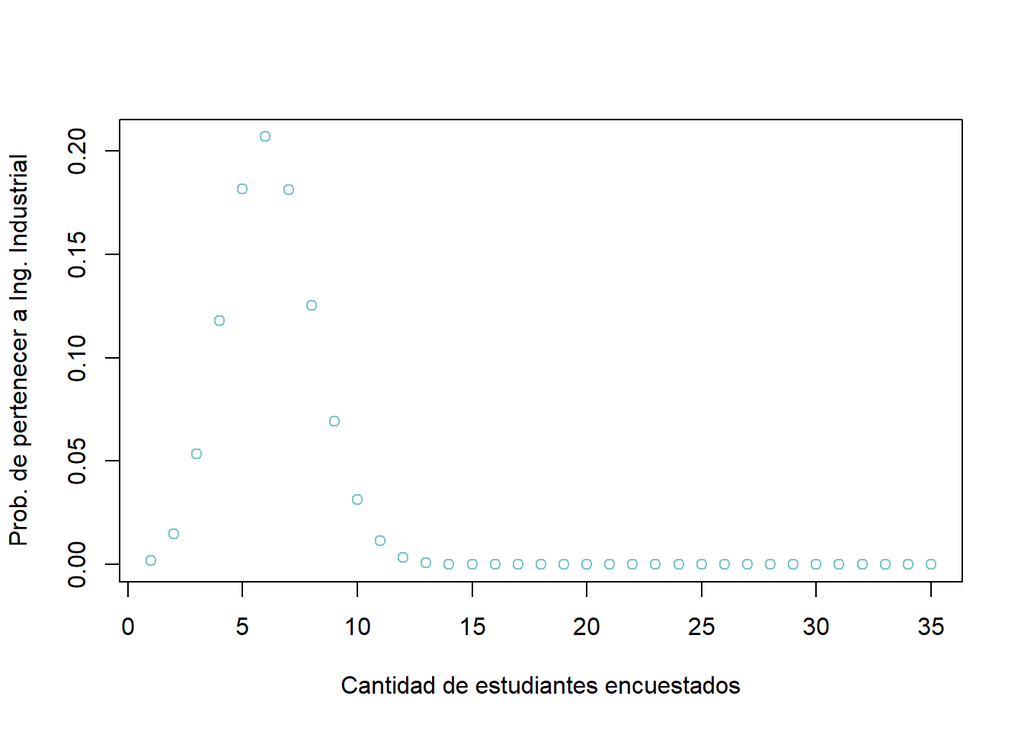

```r
x=34
M=196-x
n=30

plot(dhyper(0:x, x, M, n),col = "cadetblue3",xlab = "Cantidad de estudiantes encuestados",ylab = "Prob. de pertenecer a Ing. Industrial")
```

```r
1 -phyper(9,34,196-34,30)
```

```
## [1] 0.01620513
```

$${RESPUESTA =\ \ 0.02 }$$

**Interpretación:**

La probabilidad de que al menos 10 estudiantes, estudien ingeniería industrial, de una muestra de 30 alumnos seleccionados es de 0.02, lo cuál nos quiere decir que es muy poco probable encontrarse con una cantidad considerable de ingenieros industriales en un grupo de 30 alumnos elegidos al azar.

Hallaremos el valor esperado de la variable carrera para una muestra de 30 estudiantes.

$$Esperado = 30*(34/196)=5.2$$
**Conclusiones:**

[output not shown]